# Movie reviews

This notebook takes you though a complete iteration of Machine Learning Assignment 1 - Movie reviews. The assignment details (including links to download the data) can be found [here](https://docs.google.com/document/d/1WGYw99e5q6j5V0Zrf2HveagU6URt_kVvdR8B9HYQ99E/edit?usp=sharing).

```python
# all imports and magic commands
import numpy as np
import pandas as pd
import matplotlib.pyplot as plt
from my_measures import BinaryClassificationPerformance # my_measures written by Aaron contains all the methods we need
from sklearn.feature_extraction.text import HashingVectorizer
from sklearn.feature_extraction.text import TfidfTransformer
from scipy.sparse import csr_matrix, hstack # sparese gets the data into a format that helps us operate on it, this is what helps us remove the 0 values in our logic ops
from sklearn.preprocessing import StandardScaler
from sklearn.model_selection import train_test_split
from sklearn.feature_selection import SelectPercentile, chi2

%matplotlib inline
```

### IMPORTANT!!! Make sure you are using `BinaryClassificationPerformance` v1.02

```python
help(BinaryClassificationPerformance)
```

```
Help on class BinaryClassificationPerformance in module my_measures:

class BinaryClassificationPerformance(builtins.object)
 |  BinaryClassificationPerformance(predictions, labels, desc, probabilities=None)
 |  Performance measures to evaluate the fit of a binary classification model, v1.02
 |  Methods defined here:
 |  __init__(self, predictions, labels, desc, probabilities=None)
 |      Initialize attributes: predictions-vector of predicted values for Y, labels-vector of labels for Y
 |  compute_measures(self)
 |      Compute performance measures defined by Flach p. 57
 |  img_indices(self)
 |      Get the indices of true and false positives to be able to locate the corresponding images in a list of image names
 |  ----------------------------------------------------------------------
 |  Data descriptors defined here:
 |  __dict__
 |      dictionary for instance variables (if defined)
 |  __weakref__
 |      list of weak references to the object (if defined)
```

# Function for feature building and extraction on natural language data

(this is where we do our exprimentation for the assignment)

# function that takes raw data and completes all preprocessing required before model fits v1.0

def process_raw_data(fn, my_random_seed, test=False):

```
# read and summarize data
movie_data = pd.read_csv(fn, sep='\t')
print("movie_data is:", type(movie_data))
print("movie_data has", movie_data.shape[0], "rows and", movie_data.shape[1], "columns", "\n")
print("the data types for each of the columns in movie_data:")
print(movie_data.dtypes, "\n")
print("the first 10 rows in movie_data:")
print(movie_data.head(5))
if (not test):
    print("The rate of 'good' movie reviews in the dataset: ")
    print(movie_data['sentiment'].mean())

# vectorize Bag of Words from review text; as sparse matrix
if (not test): # fit_transform()
    hv = HashingVectorizer(n_features=2 ** 17, alternate_sign=False) # this is where we make most of our adjustments.
    # as opposed to CountVectorizer, which gives many many columns, we use hashing vectorizer is a list which removes all the non-zero values of when word doesn't appear in a string
    X_hv = hv.fit_transform(movie_data.review)
    fitted_transformations.append(hv)
    print("Shape of HashingVectorizer X:")
    print(X_hv.shape) # tells us how many words ie., the number of columns
else: # transform()
    X_hv = fitted_transformations[0].transform(movie_data.review)
    print("Shape of HashingVectorizer X:")
    print(X_hv.shape)

# http://scikit-learn.org/stable/modules/generated/sklearn.feature_extraction.text.TfidfTransformer.html
# popular words have a larger pull than others and tend to have an influence on prediction, this function prevents that event
if (not test):
    transformer = TfidfTransformer() # search for class name to learn about its parameters
    X_tfidf = transformer.fit_transform(X_hv)
    fitted_transformations.append(transformer)
else:
    X_tfidf = fitted_transformations[1].transform(X_hv)

# create additional quantitative features
# features from Amazon.csv to add to feature set
movie_data['word_count'] = movie_data['review'].str.split(' ').str.len()
movie_data['punc_count'] = movie_data['review'].str.count("\.")

X_quant_features = movie_data[["word_count", "punc_count"]]
print("Look at a few rows of the new quantitative features: ")
print(X_quant_features.head(10))

# Combine all quantitative features into a single sparse matrix
X_quant_features_csr = csr_matrix(X_quant_features)
X_combined = hstack([X_tfidf, X_quant_features_csr])
X_matrix = csr_matrix(X_combined) # convert to sparse matrix
print("Size of combined bag of words and new quantitative variables matrix:")
print(X_matrix.shape)

# Create `X`, scaled matrix of features
# feature scaling
if (not test):
    sc = StandardScaler(with_mean=False) #normalising the matrix - boolens are 0,1 while integers can be much bigger relatively
    X = sc.fit_transform(X_matrix) #final feature set of bag of words and two quant matrices
    fitted_transformations.append(sc)
    print(X.shape)
    y = movie_data['sentiment']
else:
    X = fitted_transformations[2].transform(X_matrix)
    print(X.shape)

# Create Training and Test Sets
# enter an integer for the random_state parameter; any integer will work
if (test):
    X_submission_test = X
    print("Shape of X_test for submission:")
    print(X_submission_test.shape)
    print('SUCCESS!')
    return(movie_data, X_submission_test)
else:
    X_train, X_test, y_train, y_test, X_raw_train, X_raw_test = train_test_split(X, y, movie_data, test_size=0.2, random_state=my_random_seed) #size of test set is 20% of all data
    print("Shape of X_train and X_test:")
    print(X_train.shape)
    print(X_test.shape)
    print("Shape of y_train and y_test:")
    print(y_train.shape)
    print(y_test.shape)
    print("Shape of X_raw_train and X_raw_test:")
    print(X_raw_train.shape)
    print(X_raw_test.shape)
    print('SUCCESS!')
    return(X_train, X_test, y_train, y_test, X_raw_train, X_raw_test)
```

# Version 2.0

**Feature Updates**

*Hashvectorizer Syntax*

class sklearn.feature_extraction.text.HashingVectorizer(*, input='content', encoding='utf-8', decode_error='strict', strip_accents=None, lowercase=True, preprocessor=None, tokenizer=None, stop_words=None, token_pattern='(?u)\b\w\w+\b', ngram_range=(1, 1), analyzer='word', n_features=1048576, binary=False, norm='l2', alternate_sign=True, dtype=<class 'numpy.float64'>)[source]

# function that takes raw data and completes all preprocessing required before model fits v2.0

def process_raw_data(fn, my_random_seed, test=False):

```
# read and summarize data
movie_data = pd.read_csv(fn, sep='\t')
print("movie_data is:", type(movie_data))
print("movie_data has", movie_data.shape[0], "rows and", movie_data.shape[1], "columns", "\n")
print("the data types for each of the columns in movie_data:")
print(movie_data.dtypes, "\n")
print("the first 10 rows in movie_data:")
print(movie_data.head(5))
if (not test):
    print("The rate of 'good' movie reviews in the dataset: ")
    print(movie_data['sentiment'].mean())

# vectorize Bag of Words from review text; as sparse matrix
if (not test): # fit_transform()
    hv = HashingVectorizer(n_features=2 ** 17, binary=True, alternate_sign=False) # this is where we make most of our adjustments.
    # as opposed to CountVectorizer, which gives many many columns, we use hashing vectorizer is a list which removes all the non-zero values of when word doesn't appear in a string
    X_hv = hv.fit_transform(movie_data.review)
    fitted_transformations.append(hv)
    print("Shape of HashingVectorizer X:")
    print(X_hv.shape) # tells us how many words ie., the number of columns
else: # transform()
    X_hv = fitted_transformations[0].transform(movie_data.review)
    print("Shape of HashingVectorizer X:")
    print(X_hv.shape)

# http://scikit-learn.org/stable/modules/generated/sklearn.feature_extraction.text.TfidfTransformer.html
# popular words have a larger pull than others and tend to have an influence on prediction, this function prevents that event
if (not test):
    transformer = TfidfTransformer() # search for class name to learn about its parameters
    X_tfidf = transformer.fit_transform(X_hv)
    fitted_transformations.append(transformer)
else:
    X_tfidf = fitted_transformations[1].transform(X_hv)

# create additional quantitative features
# features from Amazon.csv to add to feature set
movie_data['word_count'] = movie_data['review'].str.split(' ').str.len()
movie_data['punc_count'] = movie_data['review'].str.count("\?")

X_quant_features = movie_data[["word_count", "punc_count"]]
print("Look at a few rows of the new quantitative features: ")
print(X_quant_features.head(10))

# Combine all quantitative features into a single sparse matrix
X_quant_features_csr = csr_matrix(X_quant_features)
X_combined = hstack([X_tfidf, X_quant_features_csr])
X_matrix = csr_matrix(X_combined) # convert to sparse matrix
print("Size of combined bag of words and new quantitative variables matrix:")
print(X_matrix.shape)

# Create `X`, scaled matrix of features
# feature scaling
if (not test):
    sc = StandardScaler(with_mean=False) #normalising the matrix - boolens are 0,1 while integers can be much bigger relatively
    X = sc.fit_transform(X_matrix) #final feature set of bag of words and two quant matrices
    fitted_transformations.append(sc)
    print(X.shape)
    y = movie_data['sentiment']
else:
    X = fitted_transformations[2].transform(X_matrix)
    print(X.shape)

# Create Training and Test Sets
# enter an integer for the random_state parameter; any integer will work
if (test):
    X_submission_test = X
    print("Shape of X_test for submission:")
    print(X_submission_test.shape)
    print('SUCCESS!')
    return(movie_data, X_submission_test)
else:
    X_train, X_test, y_train, y_test, X_raw_train, X_raw_test = train_test_split(X, y, movie_data, test_size=0.2, random_state=my_random_seed) #size of test set is 20% of all data
    print("Shape of X_train and X_test:")
    print(X_train.shape)
    print(X_test.shape)
    print("Shape of y_train and y_test:")
    print(y_train.shape)
    print(y_test.shape)
    print("Shape of X_raw_train and X_raw_test:")
    print(X_raw_train.shape)
    print(X_raw_test.shape)
    print('SUCCESS!')
    return(X_train, X_test, y_train, y_test, X_raw_train, X_raw_test)
```

# Version 2.1

**Feature Updates**

*Hashvectorizer Syntax*

class sklearn.feature_extraction.text.HashingVectorizer(*, input='content', encoding='utf-8', decode_error='strict', strip_accents=None, lowercase=True, preprocessor=None, tokenizer=None, stop_words=None, token_pattern='(?u)\b\w\w+\b', ngram_range=(1, 1), analyzer='word', n_features=1048576, binary=False, norm='l2', alternate_sign=True, dtype=<class 'numpy.float64'>)[source]

# function that takes raw data and completes all preprocessing required before model fits v2.1

def process_raw_data(fn, my_random_seed, test=False):

```
# read and summarize data
movie_data = pd.read_csv(fn, sep='\t')
print("movie_data is:", type(movie_data))
print("movie_data has", movie_data.shape[0], "rows and", movie_data.shape[1], "columns", "\n")
print("the data types for each of the columns in movie_data:")
print(movie_data.dtypes, "\n")
print("the first 10 rows in movie_data:")
print(movie_data.head(5))
if (not test):
    print("The rate of 'good' movie reviews in the dataset: ")
    print(movie_data['sentiment'].mean())

# vectorize Bag of Words from review text; as sparse matrix
if (not test): # fit_transform()
    hv = HashingVectorizer(n_features=2 ** 17, binary=True, alternate_sign=False, ngram_range=(2, 3), lowercase=False) # this is where we make most of our adjustments.
    # as opposed to CountVectorizer, which gives many many columns, we use hashing vectorizer is a list which removes all the non-zero values of when word doesn't appear in a string
    X_hv = hv.fit_transform(movie_data.review)
    fitted_transformations.append(hv)
    print("Shape of HashingVectorizer X:")
    print(X_hv.shape) # tells us how many words ie., the number of columns
else: # transform()
    X_hv = fitted_transformations[0].transform(movie_data.review)
    print("Shape of HashingVectorizer X:")
    print(X_hv.shape)

# http://scikit-learn.org/stable/modules/generated/sklearn.feature_extraction.text.TfidfTransformer.html
# popular words have a larger pull than others and tend to have an influence on prediction, this function prevents that event
if (not test):
    transformer = TfidfTransformer() # search for class name to learn about its parameters
    X_tfidf = transformer.fit_transform(X_hv)
    fitted_transformations.append(transformer)
else:
    X_tfidf = fitted_transformations[1].transform(X_hv)

# create additional quantitative features
# features from Amazon.csv to add to feature set
movie_data['word_count'] = movie_data['review'].str.split(' ').str.len()
movie_data['punc_count'] = movie_data['review'].str.count("\?")

X_quant_features = movie_data[["word_count", "punc_count"]]
print("Look at a few rows of the new quantitative features: ")
print(X_quant_features.head(10))

# Combine all quantitative features into a single sparse matrix
X_quant_features_csr = csr_matrix(X_quant_features)
X_combined = hstack([X_tfidf, X_quant_features_csr])
X_matrix = csr_matrix(X_combined) # convert to sparse matrix
print("Size of combined bag of words and new quantitative variables matrix:")
print(X_matrix.shape)

# Create `X`, scaled matrix of features
# feature scaling
if (not test):
    sc = StandardScaler(with_mean=False) #normalising the matrix - boolens are 0,1 while integers can be much bigger relatively
    X = sc.fit_transform(X_matrix) #final feature set of bag of words and two quant matrices
    fitted_transformations.append(sc)
    print(X.shape)
    y = movie_data['sentiment']
else:
    X = fitted_transformations[2].transform(X_matrix)
    print(X.shape)

# Create Training and Test Sets
# enter an integer for the random_state parameter; any integer will work
if (test):
    X_submission_test = X
    print("Shape of X_test for submission:")
    print(X_submission_test.shape)
    print('SUCCESS!')
    return(movie_data, X_submission_test)
else:
    X_train, X_test, y_train, y_test, X_raw_train, X_raw_test = train_test_split(X, y, movie_data, test_size=0.2, random_state=my_random_seed) #size of test set is 20% of all data
    print("Shape of X_train and X_test:")
    print(X_train.shape)
    print(X_test.shape)
    print("Shape of y_train and y_test:")
    print(y_train.shape)
    print(y_test.shape)
    print("Shape of X_raw_train and X_raw_test:")
    print(X_raw_train.shape)
    print(X_raw_test.shape)
    print('SUCCESS!')
    return(X_train, X_test, y_train, y_test, X_raw_train, X_raw_test)
```

# Version 2.2

**Feature Updates**

*Hashvectorizer Syntax*

class sklearn.feature_extraction.text.HashingVectorizer(*, input='content', encoding='utf-8', decode_error='strict', strip_accents=None, lowercase=True, preprocessor=None, tokenizer=None, stop_words=None, token_pattern='(?u)\b\w\w+\b', ngram_range=(1, 1), analyzer='word', n_features=1048576, binary=False, norm='l2', alternate_sign=True, dtype=<class 'numpy.float64'>)[source]

# function that takes raw data and completes all preprocessing required before model fits v2.2

def process_raw_data(fn, my_random_seed, test=False):

```
# read and summarize data
movie_data = pd.read_csv(fn, sep='\t')
print("movie_data is:", type(movie_data))
print("movie_data has", movie_data.shape[0], "rows and", movie_data.shape[1], "columns", "\n")
print("the data types for each of the columns in movie_data:")
print(movie_data.dtypes, "\n")
print("the first 10 rows in movie_data:")
print(movie_data.head(5))
if (not test):
    print("The rate of 'good' movie reviews in the dataset: ")
    print(movie_data['sentiment'].mean())

# vectorize Bag of Words from review text; as sparse matrix
if (not test): # fit_transform()
    hv = HashingVectorizer(n_features=2 ** 17, binary=True, alternate_sign=False, ngram_range=(2, 3), lowercase=False) # this is where we make most of our adjustments.
    # as opposed to CountVectorizer, which gives many many columns, we use hashing vectorizer is a list which removes all the non-zero values of when word doesn't appear in a string
    X_hv = hv.fit_transform(movie_data.review)
    fitted_transformations.append(hv)
    print("Shape of HashingVectorizer X:")
    print(X_hv.shape) # tells us how many words ie., the number of columns
else: # transform()
    X_hv = fitted_transformations[0].transform(movie_data.review)
    print("Shape of HashingVectorizer X:")
    print(X_hv.shape)

# http://scikit-learn.org/stable/modules/generated/sklearn.feature_extraction.text.TfidfTransformer.html
# popular words have a larger pull than others and tend to have an influence on prediction, this function prevents that event
if (not test):
    transformer = TfidfTransformer(norm='l1', smooth_idf=False,use_idf=False) # search for class name to learn about its parameters
    X_tfidf = transformer.fit_transform(X_hv)
    fitted_transformations.append(transformer)
else:
    X_tfidf = fitted_transformations[1].transform(X_hv)

# create additional quantitative features
# features from Amazon.csv to add to feature set
movie_data['word_count'] = movie_data['review'].str.split(' ').str.len()
movie_data['punc_count'] = movie_data['review'].str.count("\?")

X_quant_features = movie_data[["word_count", "punc_count"]]
print("Look at a few rows of the new quantitative features: ")
print(X_quant_features.head(10))

# Combine all quantitative features into a single sparse matrix
X_quant_features_csr = csr_matrix(X_quant_features)
X_combined = hstack([X_tfidf, X_quant_features_csr])
X_matrix = csr_matrix(X_combined) # convert to sparse matrix
print("Size of combined bag of words and new quantitative variables matrix:")
print(X_matrix.shape)

# Create `X`, scaled matrix of features
# feature scaling
if (not test):
    sc = StandardScaler(with_mean=False) #normalising the matrix - boolens are 0,1 while integers can be much bigger relatively
    X = sc.fit_transform(X_matrix) #final feature set of bag of words and two quant matrices
    fitted_transformations.append(sc)
    print(X.shape)
    y = movie_data['sentiment']
else:
    X = fitted_transformations[2].transform(X_matrix)
    print(X.shape)

# Create Training and Test Sets
# enter an integer for the random_state parameter; any integer will work
if (test):
    X_submission_test = X
    print("Shape of X_test for submission:")
    print(X_submission_test.shape)
    print('SUCCESS!')
    return(movie_data, X_submission_test)
else:
    X_train, X_test, y_train, y_test, X_raw_train, X_raw_test = train_test_split(X, y, movie_data, test_size=0.2, random_state=my_random_seed) #size of test set is 20% of all data
    print("Shape of X_train and X_test:")
    print(X_train.shape)
    print(X_test.shape)
    print("Shape of y_train and y_test:")
    print(y_train.shape)
    print(y_test.shape)
    print("Shape of X_raw_train and X_raw_test:")
    print(X_raw_train.shape)
    print(X_raw_test.shape)
    print('SUCCESS!')
    return(X_train, X_test, y_train, y_test, X_raw_train, X_raw_test)
```

# Version 2.3

**Feature Updates**

*Hashvectorizer Syntax*

class sklearn.feature_extraction.text.HashingVectorizer(*, input='content', encoding='utf-8', decode_error='strict', strip_accents=None, lowercase=True, preprocessor=None, tokenizer=None, stop_words=None, token_pattern='(?u)\b\w\w+\b', ngram_range=(1, 1), analyzer='word', n_features=1048576, binary=False, norm='l2', alternate_sign=True, dtype=<class 'numpy.float64'>)[source]

```python
# function that takes raw data and completes all preprocessing required before model fits v2.3
def process_raw_data(fn, my_random_seed, test=False):
    # read and summarize data
    movie_data = pd.read_csv(fn, sep='\t')
    print("movie_data is:", type(movie_data))
    print("movie_data has", movie_data.shape[0], "rows and", movie_data.shape[1], "columns", "\n")
    print("the data types for each of the columns in movie_data:")
    print(movie_data.dtypes, "\n")
    print("the first 10 rows in movie_data:")
    print(movie_data.head(5))
    if (not test):
        print("The rate of 'good' movie reviews in the dataset: ")
        print(movie_data['sentiment'].mean())

    # vectorize Bag of Words from review text; as sparse matrix
    if (not test): # fit_transform()
        hv = HashingVectorizer(n_features=2 ** 17, binary=True, alternate_sign=False, ngram_range=(2, 3), lowercase=False) # this is where we make most of our adjustments.
        # as opposed to CountVectorizer, which gives many many columns, we use hashing vectorizer is a list which removes all the non-zero values of when word doesn't appear in a string
        X_hv = hv.fit_transform(movie_data.review)
        fitted_transformations.append(hv)
        print("Shape of HashingVectorizer X:")
        print(X_hv.shape) # tells us how many words ie., the number of columns
    else: # transform()
        X_hv = fitted_transformations[0].transform(movie_data.review)
        print("Shape of HashingVectorizer X:")
        print(X_hv.shape)

    # http://scikit-learn.org/stable/modules/generated/sklearn.feature_extraction.text.TfidfTransformer.html
    # popular words have a larger pull than others and tend to have an influence on prediction, this function prevents that event
    if (not test):
        transformer = TfidfTransformer(norm='l1', smooth_idf=False,use_idf=False) # search for class name to learn about its parameters
        X_tfidf = transformer.fit_transform(X_hv)
        fitted_transformations.append(transformer)
    else:
        X_tfidf = fitted_transformations[1].transform(X_hv)

    # create additional quantitative features
    # features from Amazon.csv to add to feature set
    movie_data['word_count'] = movie_data['review'].str.split(' ').str.len()
    movie_data['punc_count'] = movie_data['review'].str.count("\?")

    X_quant_features = movie_data[["word_count", "punc_count"]]
    print("Look at a few rows of the new quantitative features: ")
    print(X_quant_features.head(10))

    # Combine all quantitative features into a single sparse matrix
    X_quant_features_csr = csr_matrix(X_quant_features)
    X_combined = hstack([X_tfidf, X_quant_features_csr])
    X_matrix = csr_matrix(X_combined) # convert to sparse matrix
    print("Size of combined bag of words and new quantitative variables matrix:")
    print(X_matrix.shape)

    # SelectPercentile feature selection
    if (not test):
        selector = SelectPercentile(chi2, percentile=10)
        X_selected = selector.fit_transform(X_combined, movie_data['sentiment'])
        fitted_transformations.append(selector)
        print("Shape of X_selected after feature selection:")
        print(X_selected.shape)
    else:
        selector = fitted_transformations[2]
        X_selected_test = selector.transform(X_combined)
        print("Shape of X_selected_test after feature selection:")
        print(X_selected_test.shape)

    # Create `X`, scaled matrix of features
    # feature scaling
    if (not test):
        sc = StandardScaler(with_mean=False)
        X = sc.fit_transform(X_selected)
        fitted_transformations.append(sc)
        print("Shape of X after scaling:")
        print(X.shape)
        y = movie_data['sentiment']
    else:
        X = fitted_transformations[3].transform(X_selected)
        print("Shape of X_test after scaling:")
        print(X.shape)

    # Create Training and Test Sets
    if (test):
        X_submission_test = X
        print("Shape of X_test for submission:")
        print(X_submission_test.shape)
        print('SUCCESS!')
        return(movie_data, X_submission_test)
    else:
        X_train, X_test, y_train, y_test, X_raw_train, X_raw_test = train_test_split(X, y, movie_data, test_size=0.2, random_state=my_random_seed)
        print("Shape of X_train and X_test:")
        print(X_train.shape)
        print(X_test.shape)
        print("Shape of y_train and y_test:")
        print(y_train.shape)
        print(y_test.shape)
        print("Shape of X_raw_train and X_raw_test:")
        print(X_raw_train.shape)
        print(X_raw_test.shape)
        print('SUCCESS!')
        return(X_train, X_test, y_train, y_test, X_raw_train, X_raw_test)
```

# Create training and test sets from function

```python
# create an empty list to store any use of fit_transform() to transform() later
# it is a global list to store model and feature extraction fits
fitted_transformations = []

# CHANGE FILE PATH and my_random_seed number (any integer other than 74 will do): Use any integer apart from 24
X_train, X_test, y_train, y_test, X_raw_train, X_raw_test = process_raw_data(fn='/Users/wasimabbas/Documents/The New School/Spring 24/Machine Learning/Python/ml-master/final_data/moviereviews_train.tsv', my_random_seed=24)

print("Number of fits stored in `fitted_transformations` list: ")
print(len(fitted_transformations))
```

[output not shown]

# Fit (and tune) Various Models

common tip - look at the false negatives

### MODEL: ordinary least squares

```python
from sklearn import linear_model
ols = linear_model.SGDClassifier(loss='squared_error') # add loss='squared_loss'
ols.fit(X_train, y_train)

ols_performance_train = BinaryClassificationPerformance(ols.predict(X_train), y_train, 'ols_train')
ols_performance_train.compute_measures()
print(ols_performance_train.performance_measures)
```

```
{'Pos': 9992, 'Neg': 10008, 'TP': 6167, 'TN': 3913, 'FP': 6095, 'FN': 3825, 'Accuracy': 0.504, 'Precision': 0.5029358995269939, 'Recall': 0.6171937550040032, 'desc': 'ols_train'}
```

### MODEL: SVM, linear

```python
from sklearn import linear_model
svm = linear_model.SGDClassifier()
svm.fit(X_train, y_train)

svm_performance_train = BinaryClassificationPerformance(svm.predict(X_train), y_train, 'svm_train')
svm_performance_train.compute_measures()
print(svm_performance_train.performance_measures)
```

```
{'Pos': 9992, 'Neg': 10008, 'TP': 9992, 'TN': 10008, 'FP': 0, 'FN': 0, 'Accuracy': 1.0, 'Precision': 1.0, 'Recall': 1.0, 'desc': 'svm_train'}
```

### MODEL: logistic regression

```python
from sklearn import linear_model
lgs = linear_model.SGDClassifier(loss='log_loss') # changed from loss='log'
lgs.fit(X_train, y_train)

lgs_performance_train = BinaryClassificationPerformance(lgs.predict(X_train), y_train, 'lgs_train')
lgs_performance_train.compute_measures()
print(lgs_performance_train.performance_measures)
```

```
{'Pos': 9992, 'Neg': 10008, 'TP': 9992, 'TN': 10008, 'FP': 0, 'FN': 0, 'Accuracy': 1.0, 'Precision': 1.0, 'Recall': 1.0, 'desc': 'lgs_train'}
```

### MODEL: Naive Bayes

```python
from sklearn.naive_bayes import MultinomialNB
nbs = MultinomialNB()
nbs.fit(X_train, y_train)

nbs_performance_train = BinaryClassificationPerformance(nbs.predict(X_train), y_train, 'nbs_train')
nbs_performance_train.compute_measures()
print(nbs_performance_train.performance_measures)
```

```
{'Pos': 9992, 'Neg': 10008, 'TP': 9931, 'TN': 9934, 'FP': 74, 'FN': 61, 'Accuracy': 0.99325, 'Precision': 0.9926036981509245, 'Recall': 0.9938951160928743, 'desc': 'nbs_train'}
```

### MODEL: Perceptron

```python
from sklearn import linear_model
prc = linear_model.SGDClassifier(loss='perceptron')
prc.fit(X_train, y_train)

prc_performance_train = BinaryClassificationPerformance(prc.predict(X_train), y_train, 'prc_train')
prc_performance_train.compute_measures()
print(prc_performance_train.performance_measures)
```

```
{'Pos': 9992, 'Neg': 10008, 'TP': 9992, 'TN': 10008, 'FP': 0, 'FN': 0, 'Accuracy': 1.0, 'Precision': 1.0, 'Recall': 1.0, 'desc': 'prc_train'}
```

### MODEL: Ridge Regression Classifier

```python
from sklearn import linear_model
rdg = linear_model.RidgeClassifier()
rdg.fit(X_train, y_train)

rdg_performance_train = BinaryClassificationPerformance(rdg.predict(X_train), y_train, 'rdg_train')
rdg_performance_train.compute_measures()
print(rdg_performance_train.performance_measures)
```

```
{'Pos': 9992, 'Neg': 10008, 'TP': 9992, 'TN': 10008, 'FP': 0, 'FN': 0, 'Accuracy': 1.0, 'Precision': 1.0, 'Recall': 1.0, 'desc': 'rdg_train'}
```

### MODEL: Random Forest Classifier

```python
from sklearn.ensemble import RandomForestClassifier
rdf = RandomForestClassifier(max_depth=2, random_state=0)
rdf.fit(X_train, y_train)

rdf_performance_train = BinaryClassificationPerformance(rdf.predict(X_train), y_train, 'rdf_train')
rdf_performance_train.compute_measures()
print(rdf_performance_train.performance_measures)
```

```
{'Pos': 9992, 'Neg': 10008, 'TP': 7693, 'TN': 6707, 'FP': 3301, 'FN': 2299, 'Accuracy': 0.72, 'Precision': 0.6997453156267055, 'Recall': 0.769915932746197, 'desc': 'rdf_train'}
```

### ROC plot to compare performance of various models and fits

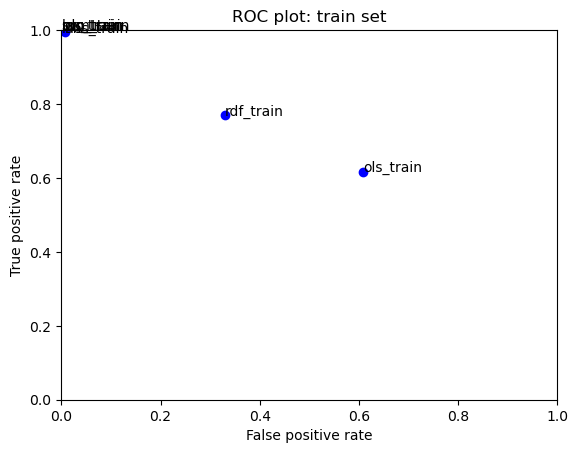

```python
fits = [ols_performance_train, svm_performance_train, lgs_performance_train, nbs_performance_train, prc_performance_train, rdg_performance_train, rdf_performance_train]

for fit in fits:
    plt.plot(fit.performance_measures['FP'] / fit.performance_measures['Neg'],
             fit.performance_measures['TP'] / fit.performance_measures['Pos'], 'bo')
    plt.text(fit.performance_measures['FP'] / fit.performance_measures['Neg'],
             fit.performance_measures['TP'] / fit.performance_measures['Pos'], fit.desc)
plt.axis([0, 1, 0, 1])
plt.title('ROC plot: train set')
plt.xlabel('False positive rate')
plt.ylabel('True positive rate')
plt.show()
```

### looking at reviews based on their classification

Let's say we decide that Ordinary Least Squares (OLS) Regression is the best model for generalization. Let's take a look at some of the reviews and try to make a (subjective) determination of whether it's generalizing well.

```python
ols_predictions = ols.predict(X_train)
```

### let's look at some false positives:

```python
# false positives

print("Examples of false positives ols:")

import random, time

for i in range(0, len(ols_predictions)):
    if (ols_predictions[i] == 1):
        if (X_raw_train.iloc[i]['sentiment'] == 0):
            if (random.uniform(0, 1) < 0.05): # to print only 5% of the false positives
                print(i)
                print(X_raw_train.iloc[i]['review'])
                print('* * * * * * * * * ')
```

[output not shown]

[output cut: 630 more lines]

```
19588
Bizarre Tobe Hooper exercise regarding an unfortunate young man(Brad Dourif)with the ability to set people on fire. This ability stems from parents who partook in atomic experiments in the 50's. They die of Spontaneous Human Combustion and it seems that what Sam is beginning to suffer from derives b…
* * * * * * * * *
19673
Lately they have been trying to hock this film late-night on cable TV commercials. Don't believe the hype. I was one of the unlucky people to see this stinker in theatres. This is, in my opinion, the 3rd Worst Movie of All Time, just behind Mac & Me (#1 Worst), and Jack Frost (#2 Worst), but I must …
* * * * * * * * *
19838
My original review of this film was simply the word sh*t written 2000 times over. Although this was a very accurate critique, I felt my review should be a little more descriptive.<br /><br />I will start with the lead actress; her facial expression doesn't change once in this film, she doesn't show …
* * * * * * * * *
19900
Tenants Two writers struggle to complete their books in an all but empty apartment house. They at first help each other and then slowly the tension between them begins to build.<br /><br />This is based upon a Bernard Malamud novel and unfortunately everyone speaks as though they are in that novel. …
* * * * * * * * *
19999
This movie is so aggrivating. The main character looks like he's 35 and I've seen scrawny beanpoles with more balls than this guy. The plot twists are so predictable its not even worth watching for the humor factor.<br /><br />Also some of the worst dialogue I've heard in 3 years, \lets go find a sm…
* * * * * * * * *
```

```python
nbs_predictions = nbs.predict(X_train)
```

```python
# false positives nbs

print("Examples of false positives nbs:")

import random, time

for i in range(0, len(nbs_predictions)):
    if (nbs_predictions[i] == 1):
        if (X_raw_train.iloc[i]['sentiment'] == 0):
            if (random.uniform(0, 1) < 0.05): # to print only 5% of the false positives
                print(i)
                print(X_raw_train.iloc[i]['review'])
                print('* * * * * * * * * ')
```

[output not shown]

```python
rdf_predictions = rdf.predict(X_train)
```

```python
# false positives rfc

print("Examples of false positives rdf:")

import random, time

for i in range(0, len(rdf_predictions)):
    if (rdf_predictions[i] == 1):
        if (X_raw_train.iloc[i]['sentiment'] == 0):
            if (random.uniform(0, 1) < 0.05): # to print only 5% of the false positives
                print(i)
                print(X_raw_train.iloc[i]['review'])
                print('* * * * * * * * * ')
```

```
Examples of false positives rdf:
124
Have you ever heard the saying that people \telegraph their intentions?\" Well in this movie, the characters' actions do more than telegraph future plans -- they show up at your house drunk and buffet you about the head. This could be forgiven if the setting had been used better, or if the character…
* * * * * * * * *
125
While some performances were good-Victoria Rowell, Adrienne Barbeau, and the two Italian girlfriends come to mind-the story was lame and derivative, the emphasis on the girlfriend's racial background was handled clumsily at best, and the relatives were mostly portrayed as stereotypes, not as real pe…
* * * * * * * * *
154
This movie is an abomination, and its making should have been considered a capital crime.<br /><br />One of the great mysteries of film-making is why nobody ever has made a faithful movie adaptation of this wonderful mystery. It is a tale of a really gripping mystery, nice old-fashioned romance, and…
* * * * * * * * *
332
Stefan is an x-con that five years ago got married to Marie. Their marriage has been stable until Stefan past catch up with them and he's offered to do a courier job. Stefan's job is a heroin delivery from Germany to Sweden which should go easily.<br /><br />In Germany Stefan meet Elli, a girl from …
* * * * * * * * *
401
Seriously, I've read some of the reviews on this film, and I have to ask, were you people watching the same movie.<br /><br />Yes, I give the set directors a lot of credit for being able to recreate 1930 vintage Los Angeles, but so what? <br /><br />None of the characters are likable, the story seem…
* * * * * * * * *
576
Incredibly muddled, off-putting and ultimately ludicrous (\the horses, oh my God, the horses!\") thriller. It's creepy at times, but it has one of the worst scripts ever written for a horror film. Watch how in the final 10 minutes everybody \"magically\" does exactly what the plot needs for the \"re…
* * * * * * * * *
599
I read Rice's novel with interest, and became quite enchanted with its characters and heartbreaking tale based on historical truths.<br /><br />However, I was simply APPALLED at this disastrous adaptation. The casting was based merely on physical appearance, and not acting talent (with the obvious e…
* * * * * * * * *
797
\After World War I, an expedition representing the Allied countries is sent to Cambodia to stop the efforts of Count Mazovia in creating a zombie like army of soldiers and laborers. Hoping to prevent a possible outbreak of war due to Mazovia's actions, the group presses through the jungle to Angkor …
* * * * * * * * *
855
Oh my, this was the worst reunion movie I have ever seen. (That is saying a lot.) I am ashamed of watching.<br /><br />What happened in the script meetings? \Ooooooh, I know! Let's have two stud muffins fall madly in love with the Most-Annoying-Character-Since-Cousin-Oliver.\" \"Yeah, that'll be coo…
* * * * * * * * *
1124
The name (Frau) of the main character is the German word for \Woman\". I don't know if that was intentional or not, but if sure got some giggles from the German audience at the Fantasy Film Festival last year, when it was shown.<br /><br />But those were the only giggles the movie got. Not that it w…
* * * * * * * * *
1225
i don't know why, but after all the hype on NPR i thought this was a new movie.....all the best footage has been used for BBC docs and NatGeo projects that you have seen if you are interested in nature programs...it has been repackaged with sappy narration and over-dramatic music for Disney to take …
* * * * * * * * *
1601
I'm dumbfounded. Yes that's right. I'm really caught here. No way did I find it awful, but on the other hand it was a frustrating experience in macabre hysterical and murky incoherency. The idea behind such a trim, minimal low-budget Indie production isn't bad, but it's a confused muddle and in the …
* * * * * * * * *
2170
I had been looking forward to seeing Dreamgirls for quite a while...what with all it's raving reviews, nominations and media attention. And I must say, the first quarter of the movie was good! It really portrayed the black music scene back then. However, as the movie wore on, me and my whole family …
* * * * * * * * *
```

[output cut: 381 more lines]

```
19195
I cheer for films that fill in subject matter gaps in world cinema. So after watching the trailer for \Water Lilies,\" I expected to like this film because I thought I'd stumbled on something unique: a movie that honestly portrays teen lesbian love - sort of a female version of \"Beautiful Thing.\" …
* * * * * * * * *
19522
LIVE A LITTLE, LOVE A LITTLE is one of Elvis' weirdest movies. Part slapstick, part fluff, part surreal and part strange. Elvis meets up with a very off-beat girl with an annoying voice. She looks like Jennifer Aniston. Story doesn't make much sense as is the case with most Elvis Presley movies, and…
* * * * * * * * *
19772
I figured that it's about time I let this one out. Pokémon fans are suffering in America these days. Why? Because we rely on Kids WB and 4Kids Entertainment to provide us with our beloved series and movies. As far as the series goes, they do a pretty good job in bringing the fun and magic of the Jap…
* * * * * * * * *
19927
We gave up at the point where George Clooney's character has his finger-nails extracted. We were not squeamish - having sat through an hour of this drivel we just knew what it felt like. To say this film was incomprehensible, boring, pretentious twaddle would be to over-praise it! How did people man…
* * * * * * * * *
19944
This was a \cute\" movie at first, then then got too sappy and featured mediocre songs, at best.<br /><br />There is too much King James English spoken with is not only annoying in today's world but not always easy to interpret. Can you imagine young people of today trying to listen to this film? Fo…
* * * * * * * * *
```

# WARNING: Don't look at test set performance too much!

The following cells show performance on your test set. Do not look at this too often!

# Look at performance on the test set

### MODEL: ordinary least squares

```python
ols_performance_test = BinaryClassificationPerformance(ols.predict(X_test), y_test, 'ols_test')
ols_performance_test.compute_measures()
print(ols_performance_test.performance_measures)
```

```
{'Pos': 2508, 'Neg': 2492, 'TP': 1656, 'TN': 825, 'FP': 1667, 'FN': 852, 'Accuracy': 0.4962, 'Precision': 0.498344869094192, 'Recall': 0.6602870813397129, 'desc': 'ols_test'}
```

### MODEL: SVM, linear

```python
svm_performance_test = BinaryClassificationPerformance(svm.predict(X_test), y_test, 'svm_test')
svm_performance_test.compute_measures()
print(svm_performance_test.performance_measures)
```

```
{'Pos': 2508, 'Neg': 2492, 'TP': 1935, 'TN': 1934, 'FP': 558, 'FN': 573, 'Accuracy': 0.7738, 'Precision': 0.776173285198556, 'Recall': 0.7715311004784688, 'desc': 'svm_test'}
```

### MODEL: logistic regression

```python
lgs_performance_test = BinaryClassificationPerformance(lgs.predict(X_test), y_test, 'lgs_test')
lgs_performance_test.compute_measures()
print(lgs_performance_test.performance_measures)
```

```
{'Pos': 2508, 'Neg': 2492, 'TP': 1950, 'TN': 1927, 'FP': 565, 'FN': 558, 'Accuracy': 0.7754, 'Precision': 0.7753479125248509, 'Recall': 0.777511961722488, 'desc': 'lgs_test'}
```

### MODEL: Naive Bayes

```python
nbs_performance_test = BinaryClassificationPerformance(nbs.predict(X_test), y_test, 'nbs_test')
nbs_performance_test.compute_measures()
print(nbs_performance_test.performance_measures)
```

```
{'Pos': 2508, 'Neg': 2492, 'TP': 2076, 'TN': 1973, 'FP': 519, 'FN': 432, 'Accuracy': 0.8098, 'Precision': 0.8, 'Recall': 0.8277511961722488, 'desc': 'nbs_test'}
```

### MODEL: Perceptron

```python
prc_performance_test = BinaryClassificationPerformance(prc.predict(X_test), y_test, 'prc_test')
prc_performance_test.compute_measures()
print(prc_performance_test.performance_measures)
```

```
{'Pos': 2508, 'Neg': 2492, 'TP': 1933, 'TN': 1933, 'FP': 559, 'FN': 575, 'Accuracy': 0.7732, 'Precision': 0.7756821829855538, 'Recall': 0.7707336523125997, 'desc': 'prc_test'}
```

### MODEL: Ridge Regression Classifier

```python
rdg_performance_test = BinaryClassificationPerformance(rdg.predict(X_test), y_test, 'rdg_test')
rdg_performance_test.compute_measures()
print(rdg_performance_test.performance_measures)
```

```
{'Pos': 2508, 'Neg': 2492, 'TP': 2024, 'TN': 2029, 'FP': 463, 'FN': 484, 'Accuracy': 0.8106, 'Precision': 0.8138319260152794, 'Recall': 0.8070175438596491, 'desc': 'rdg_test'}
```

### MODEL: Random Forest Classifier

```python
rdf_performance_test = BinaryClassificationPerformance(rdf.predict(X_test), y_test, 'rdf_test')
rdf_performance_test.compute_measures()
print(rdf_performance_test.performance_measures)
```

```
{'Pos': 2508, 'Neg': 2492, 'TP': 1830, 'TN': 1597, 'FP': 895, 'FN': 678, 'Accuracy': 0.6854, 'Precision': 0.671559633027523, 'Recall': 0.7296650717703349, 'desc': 'rdf_test'}
```

### ROC plot to compare performance of various models and fits

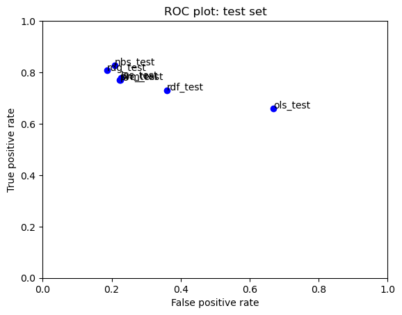

```python
fits = [ols_performance_test, svm_performance_test, lgs_performance_test, nbs_performance_test, prc_performance_test, rdg_performance_test, rdf_performance_test]

for fit in fits:
    plt.plot(fit.performance_measures['FP'] / fit.performance_measures['Neg'],
             fit.performance_measures['TP'] / fit.performance_measures['Pos'], 'bo')
    plt.text(fit.performance_measures['FP'] / fit.performance_measures['Neg'],
             fit.performance_measures['TP'] / fit.performance_measures['Pos'], fit.desc)
plt.axis([0, 1, 0, 1])
plt.title('ROC plot: test set')
plt.xlabel('False positive rate')
plt.ylabel('True positive rate')
plt.show()
```

# SUBMISSION

only come here when ready to make a submission

```python
# read in test data for submission
# CHANGE FILE PATH and my_random_seed number (any integer other than 74 will do):
raw_data, X_test_submission = process_raw_data(fn='/home/ec2-user/data/moviereviews_test.tsv', my_random_seed=74, test=True) # make sure the file path is changed, and change random seed to your number
print("Number of rows in the submission test set (should be 25,000): ")
```

[output not shown]

[output cut: 16 more lines]

[output not shown]

Choose a *single* model for your submission. In this code, I am choosing the Ordinary Least Squares model fit, which is in the `ols` object. But you should choose the model that is performing the best for you!

```python
# store the id from the raw data
my_submission = pd.DataFrame(raw_data["id"])
# concatenate predictions to the id
my_submission["prediction"] = ols.predict(X_test_submission)
# look at the proportion of positive predictions
print(my_submission['prediction'].mean())
```

```
0.5596
```

```python
raw_data.head()
```

|  | id | review | word_count | punc_count |
| --- | --- | --- | --- | --- |
| 0 | 12311_10 | Naturally in a film who's main themes are of m... | 131 | 5 |
| 1 | 8348_2 | This movie is a disaster within a disaster fil... | 169 | 15 |
| 2 | 5828_4 | All in all, this is a movie for kids. We saw i... | 176 | 18 |
| 3 | 7186_2 | Afraid of the Dark left me with the impression... | 112 | 5 |
| 4 | 12128_7 | A very accurate depiction of small time mob li... | 133 | 8 |

```python
my_submission.head()
```

|  | id | prediction |
| --- | --- | --- |
| 0 | 12311_10 | 1 |
| 1 | 8348_2 | 1 |
| 2 | 5828_4 | 1 |
| 3 | 7186_2 | 1 |
| 4 | 12128_7 | 0 |

```python
my_submission.shape
```

```
(25000, 2)
```

```python
# export submission file as pdf
# CHANGE FILE PATH:
my_submission.to_csv('/home/ec2-user/data/moviereviews_submission.csv', index=False)
```

# Submit to Canvas: 1) the CSV file that was written in the previous cell and 2) the url to the repository (GitHub or other) that contains your code and documentation